# 비모수 회귀모형 실습

이용희

2019년 11월 18일

## 비모수 회귀모형과 편이-분산의 관계(Bias-Variance Tradeoff)

반응변수 $Y$와 설명변수 $X$가 다음과 같은 관계를 가진다고 하자.
$$E(Y|X=x) = m(x)$$
이러한 관계를 회귀모형(regression model)이라고 하며 $Y$의 평균이 $X$에 따라서 변하는 괸계를 설정하는 모형이다. 만약 $m(x)$의 형태를 회귀계수의 선형식으로 나타낼 수 있다면 우리는 이를 선형회귀모형(linear regression model)이라고 한다.
$$m(x) = \beta_1 x_1 + \beta_2 x_2 + \dots + \beta_p x_p$$
설명변수는 고정된 값이거나 또는 확률변수일 수도 있다.

비모수 회귀모형(nonparametric regression model)에서는 $m(x)$의 형태에 특별한 제한을 두지 않는다. 따라서 함수 $m(x)$는 무수히 많고 다양한 형태를 가질 수 있다. $n$개의 독립표본 $(Y_1,X_1),(Y_2,X_2),\dots,(Y_n,X_n)$이 주어지면 비모수 회귀모형을 다음과 같이 기술할 수 있다.
$$Y_i = m(X_i) + e_i$$
여기서 $X_i$와 독립인 오차항 $e_i$는 서로 독립이고 평균이 0이며 분산이 $\tau^2$인 확률변수로 가정한다. 따라서 설명변수의 값이 $x$라면 아래와 같이 나타낼 수 있다.
$$E(Y_i|X_i =x) = E[ m(X_i) + e_i | X_i =x] = m(x)$$

만약 $\hat m(x)$가 $m(x)$의 추정량이라면 예측위험함수(prediction risk, prediction error) $R(m, \hat m)$는 다음과 같이 정의되고분해할 수 있다. 아래의 식을 유도할 때 편의상 $X$는 확률변수가 아닌 고정된 값이라고 할 것이며 확률변수인 경우에도 유사한 결과를 얻는다.

$$\begin{align*}
R(m, \hat m) & = E[Y - \hat m(X)) ]^2 \\
&= E[ (Y - m(X) + m(X) -E(\hat m(X)) + E(\hat m(X)) -\hat m(X) ]^2 \\
&= E[ (Y - m(X) ]^2 + E[m(X) -E(\hat m(X)) ]^2 + E[\hat m(X) -E(\hat m(X))]^2 + cross-product-terms
\end{align*}$$

위의 식에서 다음과 같은 결과를 이용하면 교차항들(cross-product terms)은 0이 됨을 보일 수 있으며
$$E [Y - m(X) ] =E(e) = 0, \quad E[\hat m(X) -E(\hat m(X))] =0$$
또한 다음과 같은 관계를 이용하면
$$E [Y - m(X) ]^2 =E(e^2) = \tau^2, \quad m(X) -E(\hat m(X)) = bias(\hat m(X)), \quad E[\hat m(X) -E(\hat m(X))]^2 = Var(\hat m(X))$$
다음과 같이 예측위험함수의 분해가 가능하다.
$$R(m, \hat m) = E[Y - \hat m(X) ]^2= \tau^2 + [bias(\hat m(X))]^2 + Var(\hat m(X))$$
위의 식에서 $X$가 확률변수이면 먼저 $X$가 주어진 조건부 기대값을 생각하고 위와 같이 유도하면 다음과 같이 나타낼 수 있다.
$$\begin{align*}
R(m, \hat m) & = E[Y - \hat m(X))^2 ]^2 \\
& = E \left \{ E[ (Y - \hat m(X))^2 |X=x ] \right \} \\
& = \tau^2 + \int [bias(\hat m(x))]^2 dP(x) + \int Var(\hat m(x)) dP(x)
\end{align*}$$

## Regressogram

Regressogram은 histogrm을 회귀모형에 적용한 방법이다. 아래의 함수 `regressogram`은 설명변수 벡터 `x`와 반응변수 벡터 `y` 를 인자로 받으며 구간 `(left, right)` 를 `k`개의 구간으로 나누어 각 구간마다 반응값들의 평균을 구해주는 함수이다. 이렇게 주어진 구간에서 평균값을 이용하여 회귀식을 추정하는 모형을 국소회귀(local regression)이라고 한다.

```r
regressogram = function(x,y,left,right,k,plotit,xlab="",ylab="",sub=""){
  ### assumes the data are on the interval [left,right]
  n = length(x)
  B = seq(left,right,length=k+1)
  WhichBin = findInterval(x,B)
  N = tabulate(WhichBin)
  m.hat = rep(0,k)
  for(j in 1:k){
    if(N[j]>0)m.hat[j] = mean(y[WhichBin == j])
  }
  if(plotit==TRUE){
    a = min(c(y,m.hat))
    b = max(c(y,m.hat))
    plot(B,c(m.hat,m.hat[k]),lwd=3,type="s",
         xlab=xlab,ylab=ylab,ylim=c(a,b),col="blue",sub=sub)
    points(x,y)
  }
  return(list(bins=B,m.hat=m.hat))
}
```

위의 프로그램에서 `findInterval(x,B)`은 전체 구간 `B`의 각 구간에 벡터 `x` 의 값들이 속해있는 정보를 계산해준다. 예를 들어서 $(0,10)$ 구간을 4개로 나누고 $(1,2,2,4,6,7,8)$의 값이 어떤 구간에 속해있는지 다음과 같이 알 수 있다.

```r
B = seq(0,10,length=5)
B
```

```
## [1]  0.0  2.5  5.0  7.5 10.0
```

```r
x = c(1,2,2,4,6,7,8)
findInterval(x,B)
```

```
## [1] 1 1 1 2 3 3 4
```

$$m(x) = 3 \sin(8x)$$
이제 구간의 수를 $k=5,10,20$ 으로 바꾸면서 regressogram이 어떤 형태로 $m(x)$를 추정하는지 알아보자.

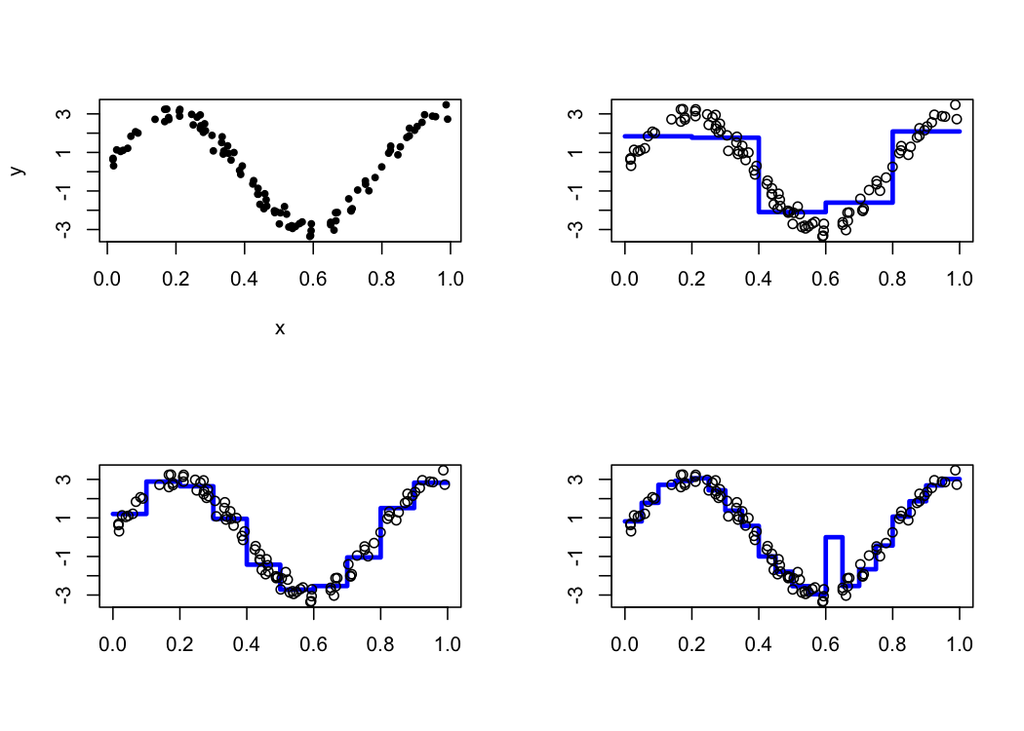

```r
par(mfrow=c(2,2))
n = 100
x = runif(n)
y = 3*sin(8*x) + rnorm(n,0,.3)
plot(x,y,pch=20)
out = regressogram(x,y,left=0,right=1,k=5,plotit=TRUE)
out = regressogram(x,y,left=0,right=1,k=10,plotit=TRUE)
out = regressogram(x,y,left=0,right=1,k=20,plotit=TRUE)
```

이제 라이브러리 `ElemStatLearn`에 있는 실제 자료 `bone`를 이용하여 regressogram 을 그려보자. 자료 `bone`의 반응변수는 `density` (Measurements in the bone mineral density) 이며 설명변수는 나이(`age`)이다. 남자와 여자를 따로 그렸으며 구간의 크기는 각각 $k=10$과 $k=20$을 사용해 보았다.

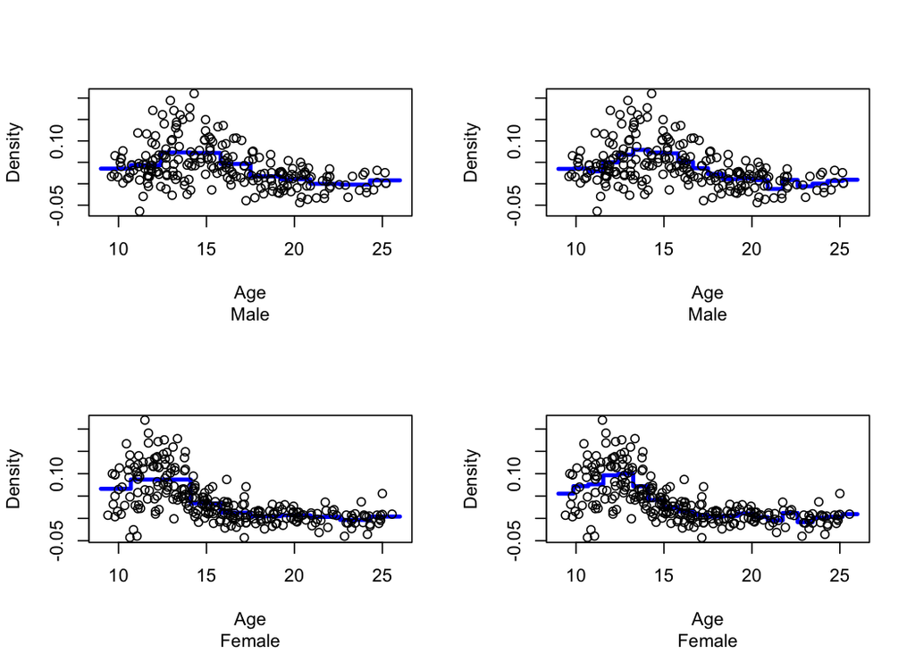

```r
par(mfrow=c(2,2))
#install.packages("ElemStatLearn")
library(ElemStatLearn)
attach(bone)
age.male = age[gender == "male"]
density.male = spnbmd[gender == "male"]
out = regressogram(age.male,density.male,left=9,right=26,k=10,plotit=TRUE,
                   xlab="Age",ylab="Density",sub="Male")
out = regressogram(age.male,density.male,left=9,right=26,k=20,plotit=TRUE,
                   xlab="Age",ylab="Density",sub="Male")
age.female = age[gender == "female"]
density.female = spnbmd[gender == "female"]
out = regressogram(age.female,density.female,left=9,right=26,k=10,plotit=TRUE,xlab="Age",ylab="Density",sub="Female")
out = regressogram(age.female,density.female,left=9,right=26,k=20,plotit=TRUE,xlab="Age",ylab="Density",sub="Female")
```

## 커널추정

### 커널추정법

국소회귀에서 가장 많이 사용되는 방법이 커널추정(kernel estimation) 방법이다. 다음의 함수 `kernel(x,y,grid,h)`은 표준편차의 크기가 $h$인 정규분포 확률밀도함수를 커널로 이용하여 주어진 값 $x$에서 반응변수 $y$들의 가중평균을 구해주는 함수이다. 변수 `grid`는 `x`축에서 커널을 계산할 떄 사용되는 점들 모아놓은 벡터이다.

$$\hat m(x) = \frac{ \sum_{i=1}^n K \left ( \frac{x -X_i}{h} \right ) Y_i }
{ \sum_{i=1}^n K \left ( \frac{x -X_i}{h} \right ) } , \quad
K \left ( \frac{x -y}{h} \right ) = (2\pi h^2)^{-1/2} \exp \left ( - \frac{(x -y)^2 }{2h^2} \right )$$

```r
kernel = function(x,y,grid,h){
  ### kernel regression estimator at a grid of values
  n = length(x)
  k = length(grid)
  m.hat = rep(0,k)
  for(i in 1:k){
    w = dnorm(grid[i],x,h)
    m.hat[i] = sum(y*w)/sum(w)
  }
  return(m.hat)
}
```

다음의 함수 `kernel.fitted(x,y,h)`는 주어진 자료벡터 `x`,`y`와 구간의 크기 `h`에 대하여 반응변수의 예측값 $\hat Y_i =\hat m_h(X_i)$ 을 커널추정으로 구해준다.

$$\hat Y_i = \hat m(X_i) = \frac{ \sum_{j=1}^n K \left ( \frac{X_i -X_j}{h} \right ) Y_i }
{ \sum_{j=1}^n K \left ( \frac{X_i -X_j}{h} \right ) } = \sum_{j=1}^{n} l_j(X_i) Y_i$$

또한 위의 식에서 $L_{ij} = l_j(X_i)$라고 하면 다음과 같은 선형예측식에서 $n \times n$ 행렬 $L = \{ L_{ij} \}$의 대각원소 $L_{ii}$도 계산해준다.

$$\hat Y = L Y$$

```r
kernel.fitted = function(x,y,h){
  ### fitted values and diaginal of smoothing matrix
  n = length(x)
  m.hat = rep(0,n)
  S = rep(0,n)
  for(i in 1:n){
    w = dnorm(x[i],x,h)
    w = w/sum(w)
    m.hat[i] = sum(y*w)
    S[i] = w[i]
  }
  return(list(fitted=m.hat,S=S))
}
```

### 최적 구간의 길이 선택

다음의 함수 `CV(x,y,H)`는 자료벡터 `x`,`y`와 서로 다른 $h$의 값들을 모아 놓은 벡터 `H`를 받아서 다음과 같은 cross-validation의 값 $CV$, $GCV$, $\nu$를 계산해 주는 함수이다.

$$\begin{align*}
CV & = \frac{1}{n} \sum_i^n [ Y_i - \hat m_h^{(-i)} (X_i) ] ^2
= \frac{1}{n} \sum_i^n \left ( \frac {Y_i - \hat m_h (X_i) }{1-L_{ii}} \right )^2 \\
GCV & = \frac{1}{ \left ( 1-\frac{\nu}{n} \right )^2 } \frac{1}{n} \sum_i^n ( Y_i - \hat m_h (X_i))^2 \\
\nu &= trace(L)
\end{align*}$$

```r
CV = function(x,y,H){
  ### H is a vector of bandwidths
  n = length(x)
  k = length(H)
  cv = rep(0,k)
  nu = rep(0,k)
  gcv = rep(0,k)
  for(i in 1:k){
    tmp = kernel.fitted(x,y,H[i])
    cv[i] = mean(((y - tmp$fitted)/(1-tmp$S))^2)
    nu[i] = sum(tmp$S)
    gcv[i] = mean((y - tmp$fitted)^2)/(1-nu[i]/n)^2
  }
  return(list(cv=cv,gcv=gcv,nu=nu))
}
```

이제 위에서 보았던 `bone` 자료에 대한 회귀식을 커널로 추정하려고 한다. 이때 CV 또는 GCV를 최소화하는 구간의 크기(bandwidth) $h$를 찾기위하여 구간 $(0.1,5)$안에서 20개의 $h$값에 대한 CV 또는 GCV 값을 계산한다. 아래는 CV 또는 GCV 값을 최소로 하는 $h$값을 찾는 프로그램이다.

```r
par(mfrow=c(1,2))
H = seq(.1,5,length=20)
H
```

```
##  [1] 0.1000000 0.3578947 0.6157895 0.8736842 1.1315789 1.3894737 1.6473684
##  [8] 1.9052632 2.1631579 2.4210526 2.6789474 2.9368421 3.1947368 3.4526316
## [15] 3.7105263 3.9684211 4.2263158 4.4842105 4.7421053 5.0000000
```

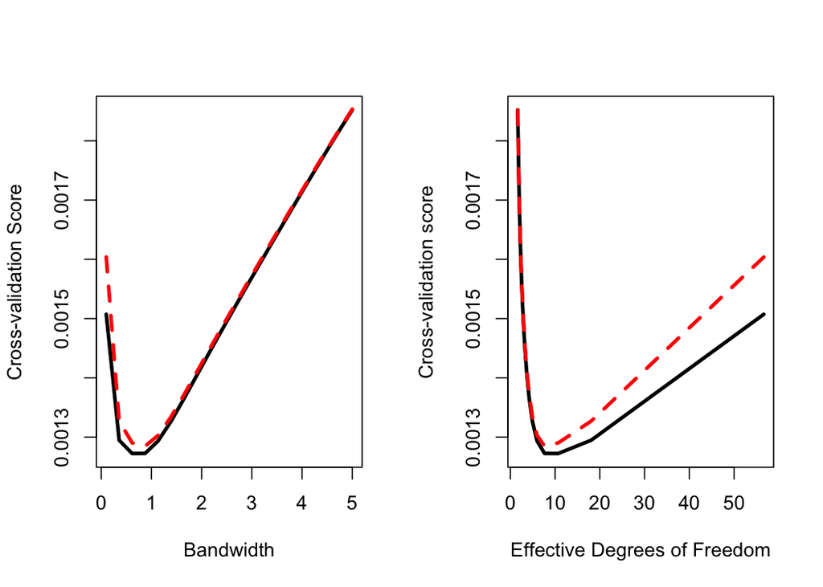

```r
out = CV(age.female,density.female,H)
plot(H,out$cv,type="l",lwd=3,xlab="Bandwidth",ylab="Cross-validation Score")
lines(H,out$gcv,lty=2,col="red",lwd=3)
plot(out$nu,out$cv,type="l",lwd=3,xlab="Effective Degrees of Freedom",ylab="Cross-validation score")
lines(out$nu,out$gcv,lty=2,col="red",lwd=3)
```

```r
j = which.min(out$cv)
h = H[j]
h
```

```
## [1] 0.6157895
```

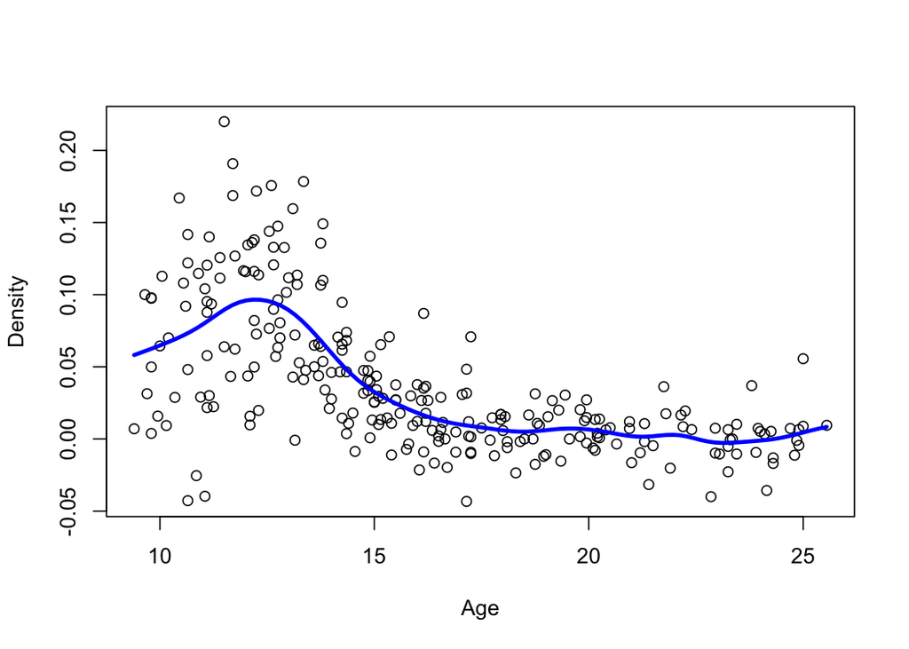

```r
par(mfrow=c(1,1))
grid = seq(min(age.female),max(age.female),length=100)
m.hat = kernel(age.female,density.female,grid,h)
plot(age.female,density.female,xlab="Age",ylab="Density")
lines(grid,m.hat,lwd=3,col="blue")
```

위의 그래프는 선택된 $h=0.6157895$을 이용하여 추정한 반응변수 `density` 의 커널회귀 함수 $\hat m(x)$ 이다.

### 붓스트랩 신뢰 구간

다음 프로그램은 붓스트랩(Bootstrap)을 이용하여 주어진 $x$값에서 추정량 $\hat m(x)$의 표준오차 $SE(x)$를 구하는 프로그램이다.

```r
boot = function(x,y,grid,h,B){
  ### pointwise standard error for kernel regression using the bootstrap
  k = length(grid)
  n = length(x)
  M = matrix(0,k,B)
  for(j in 1:B){
    I = sample(1:n,size=n,replace=TRUE)
    xx = x[I]
    yy = y[I]
    M[,j] = kernel(xx,yy,grid,h)
  }
  s = sqrt(apply(M,1,var))
  return(s)
}
```

아래는 추정량 $\hat m(x)$의 95% 신뢰구간을 구하는 프로그램이다. 붓스트랩의 반복수는 $B=1000$이다.

$$CI(x) = [\hat m(x) - 2 SE(x) , \hat m(x) + 2 SE(x) ]$$

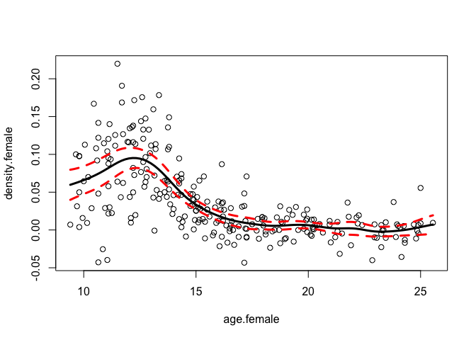

```r
par(mfrow=c(1,1))
h = .7
grid = seq(min(age.female),max(age.female),length=100)
plot(age.female,density.female)
mhat = kernel(age.female,density.female,grid,h)
lines(grid,mhat,lwd=3)
B = 1000
se = boot(age.female,density.female,grid,h,B)
lines(grid,mhat+2*se,lwd=3,lty=2,col="red")
lines(grid,mhat-2*se,lwd=3,lty=2,col="red")
```